# Univariate Plots Section

# Multivariate Plots Section

Expanding on the findings in the bivariant section where the level of alcohol and volatile acidity both have an effect on the quality of wine. I want to see if they only act independently. So I am going to create plots of volatile acidity, alcohol and quality.

#### Quality

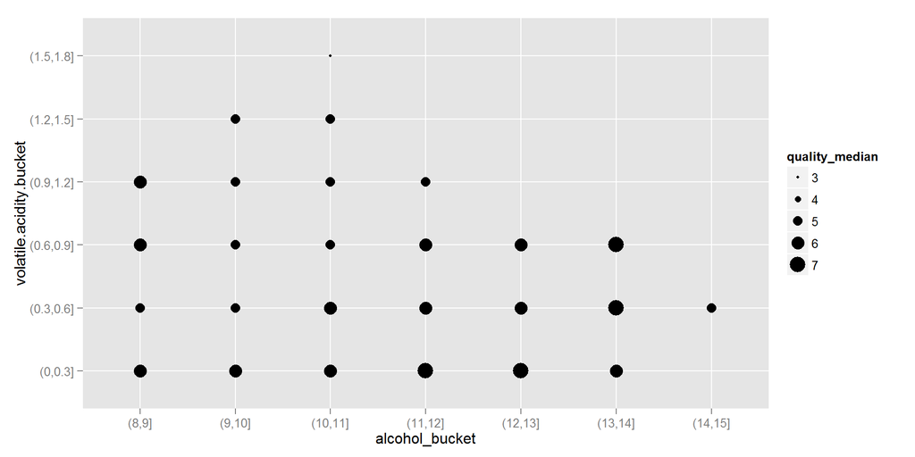

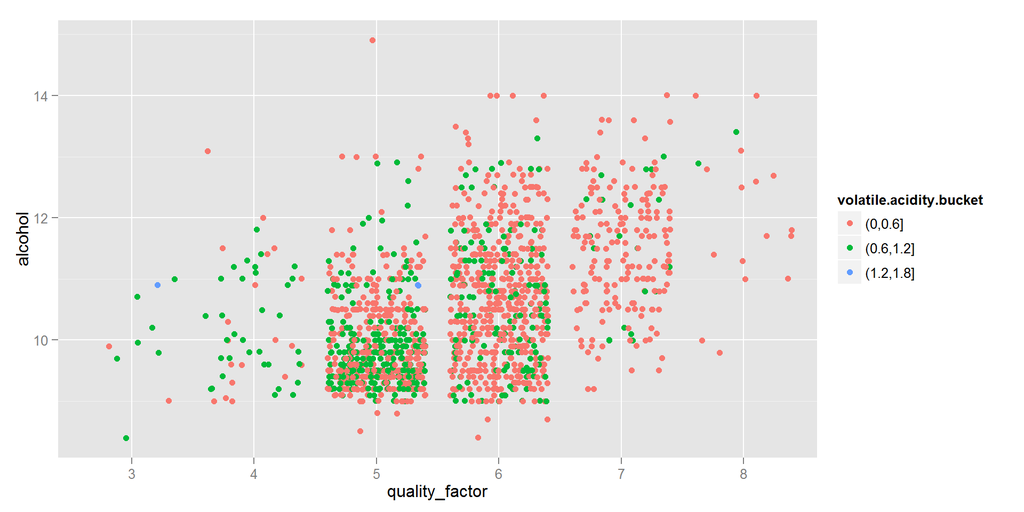

On the first plot, there is a cluster of larger dots on the low right of the first plot. This means that wines that are **higher in alcohol and lower and volatile acidity have high ratings**.

For the second plot, I grouped the volatile acidity values into larger buckets to make it easier to see patterns in a plot. This plot also shows that the number of low volalile acid plots (orange) increases as the alcohol level and quality increases.

In the bivariant plots, I saw that citric acid decreases as volatile acid increases. How do these 2 variables, effect quality? At what level(s) of citric acid and volatile acid are ideal for a good quality wine?

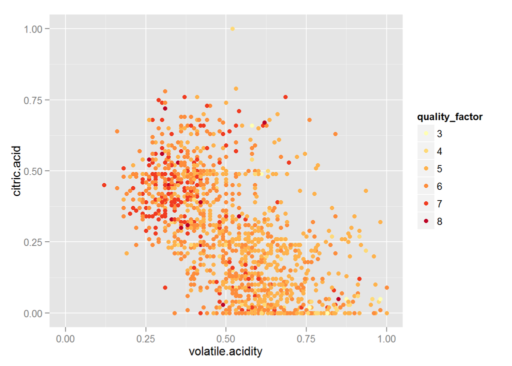

The darker shades of the plot mean higher quality. I can see a cluster of darker plots with citric acid > 0.25 abd volatile acidity < 0.4. This suggests that **low volatile acidity and high citric acid have better quality**.

In the bivariant plot section I found that there was a relationship between fixed acidity and citric acid. Is there a relationship between these 2 variables with quality?

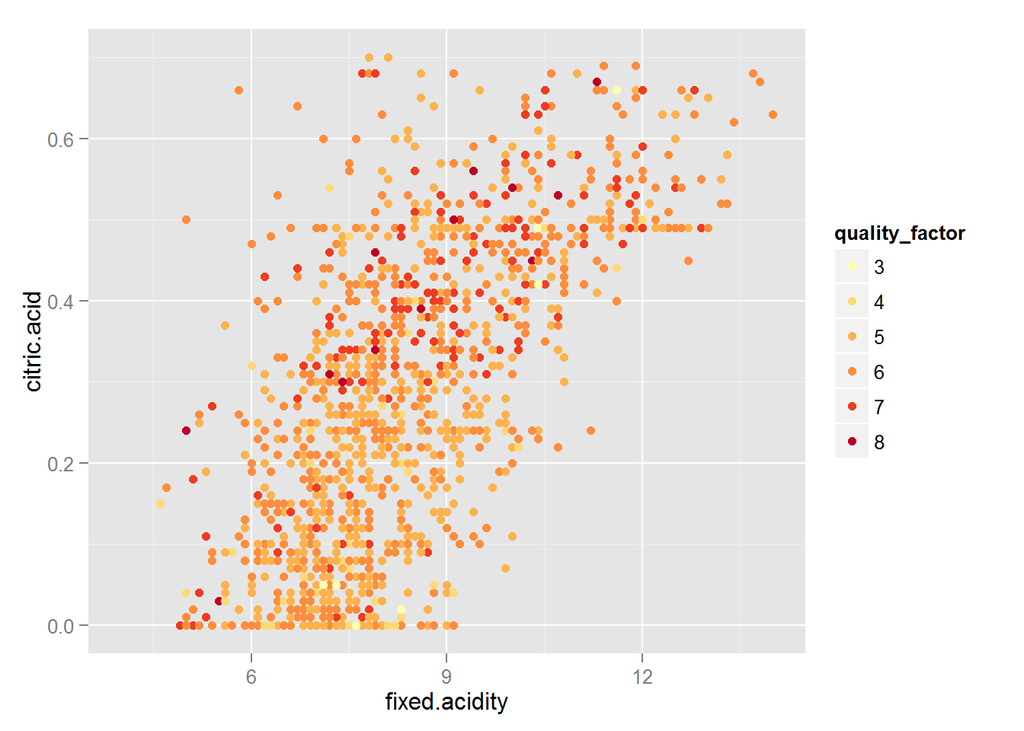

The relationship here is not as strong as the one with volatile acid. The clusters of higher quality wines are more spread out.

#### Density

I want to look the effect of some of the variables to density. In the previous section I found that density increases as any acid or sugar increased and it decreased as alcohol increased. In relative terms (against each other) I want to see how these variables effect density.

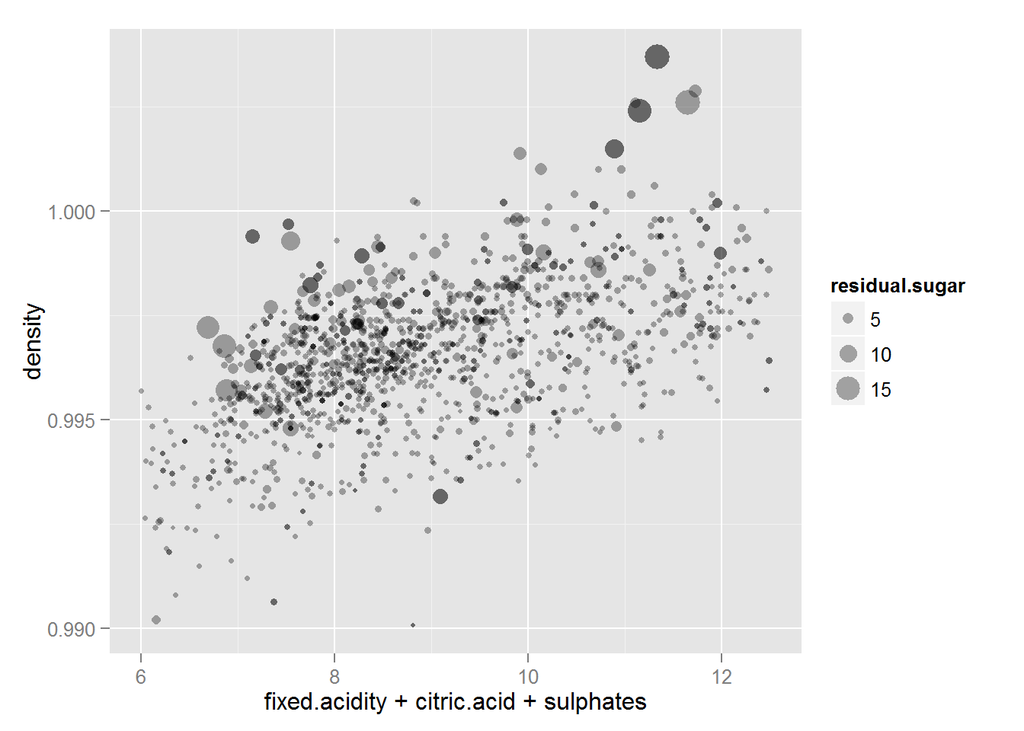

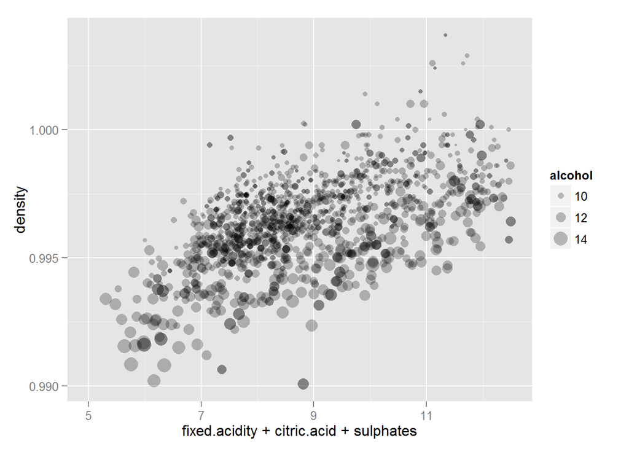

Tartaric acid (fixed acidity), citric acid and sulphates have a density higher than water, so, I expect the density to increase as the total volume of these substances increase. I also wondered what kind of relative impact alcohol and sugar would have on density. The effect of alcohol and sugar can be seen in the large points outside of the main cluster of plots.

We can see that **higher levels of alcohol reduces the density** when compared to other wines with similar amounts of acids and sulphates.

# Multivariate Analysis

### Talk about some of the relationships you observed in this part of the investigation. Were there features that strengthened each other in terms of looking at your feature(s) of interest?

When plotting the quality, volatile acidity and alcohol together I found that both alcohol and volatile acidity can be used together to influence the quality where higher quality wines tend to have higher alcohol and lower volatile acidity.

There was also a relationship between citric acid, volatile acidity and quality. I found that wines with quality 7 or higher tend to have higher levels of citric acid and lower volatile acidity. It was interesting that fixed acidity and citric acid did not have the same effect on quality, where the clusters ofhigh quality wines were much more spread out on the plot.

### Were there any interesting or surprising interactions between features?

Fixed acidity did not have same effect on quality as volatile acidity where high quality wines had a large ranges of fixed acidity values.

The relationship between density and alcohol, fixed acidity, citric acids and sulphates was interesting. In the plot of the acids and sulphates with the density and alcohol level we can see the impact on each on the density. I decided to group the acids and sulphates into a single variable because they all have similar level of densities and are higher than water.

As the total amount of acid and sulphates increases, the density also increases. Alcohol level also has a large effect where higher levels reduce the density. Alternatively, residual sugar has the opposite effect as alcohol where more sugar means higher density.

### OPTIONAL: Did you create any models with your dataset? Discuss the strengths and limitations of your model.

# Final Plots and Summary

### Plot One

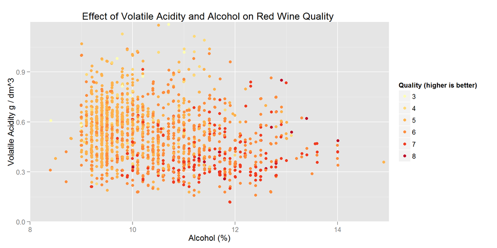

### Plot Two

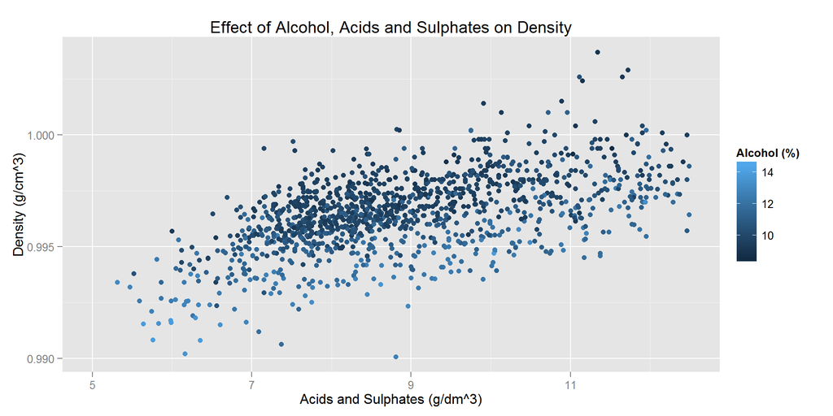

### Description Two

As the amount of fixed acidity, citric acid and sulphates increase, density also increases. This effect is offset by alcohol where higher levels result in lower density. The impact of alcohol is apparent in the reduction in density where the level of acids are the same.

### Plot Three

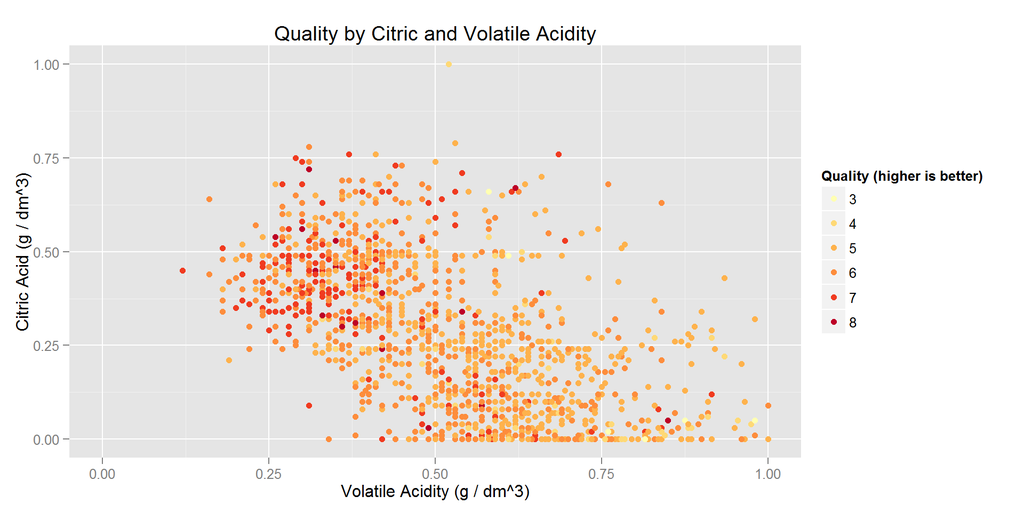

# Reflection

The dataset contains information on almost 1600 Portuguese “Vinho Verde” red wines. I started by getting an understanding of the meaning of each individual variable and what they looked like in the data. Once I had an understanding of the variables I plotted a correlation matrix and see which pairs of variables have relationships to get an idea of which bivariant plots I should investigate.

The bivariant plots revealed some relationships with quality where higher levels of the following variables increased quality: * alcohol level * sulphates * citric acid

Lower levels of the following increase quality: * volatile acidity

I had difficulty with multivariant analysis. I found that the lack of categorical variables made it difficult to come up with meaningful plots. I do not have any domain knowledge in wines and checmicals, so it was difficult in finding good combinations of variables to show in plots. To overcome this, I took the approach of enhancing my more interest bivariant plots by including extra variables which might make it more interesting.

I felt I had good success in the univariant and bivariant analysis sections. In the univariant section, I was able to get an understanding of what the data was like for each variable. In the bivariant analysis, I was able to find related variables and understand how they interacted with one another. I was able to increase my understanding of what each variable actually is, for example, I did not know what density was, but after analysing the data against alcohol and acids I worked out that it was the “thickness” of the wine.

The next step would be to do some additional statistical analysis such as regression modelling to get more detailed insights on how each of the variables in the dataset relate to quality.